# 904971914_stats102c_hw5

Xiaoshu Luo

2020/12/9

## Question 1

**(a)**

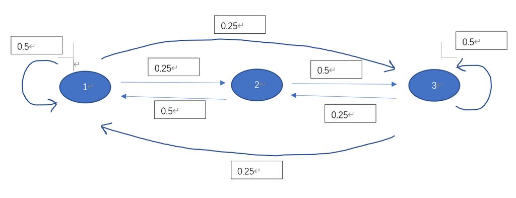

$$

$$\begin{eqnarray}
\begin{pmatrix}
0.5 & 0.25 & 0.25&\\
0.5 & 0 & 0.5 \\
0.25 & 0.25&0.5 \\
\end{pmatrix}
\end{eqnarray}$$

$$

**(b)**  
p(rainy in two days)= 0.25x0.5 + 0.25x0.5 + 0.5x0.25=0.125+0.125+0.125 = 0.375  
p(cloudy in two days)= 0.25 x 0.25 + 0.25x0 + 0.5x0.25=0.0625+0+0.125= 0.1875  
p(sunny in two days)= 0.25x0.25 + 0.25x0.5 + 0.5x0.5 = 0.0625 + 0.125 + 0.25 = 0.4375 So the expected weather is sunny.

**(c)**
Yes, it is irreducible because there is at least one path between each two states, so all states communicate with each other. The stationary distribution is:
$$

$$\begin{eqnarray}
\pi_1 = 0.5\pi_1 + 0.5\pi_2 +0.25\pi_3\\
\pi_2 = 0.25\pi_1 + 0*\pi_2 +0.25\pi_3\\
\pi_3 = 0.25\pi_1 + 0.5\pi_2 +0.5\pi_3\\
1 =\pi_1 + \pi_2 +\pi_3\\
\pi_1 = 0.4,\pi_2=0.2,\pi_3=0.4
\end{eqnarray}$$

$$

## Question 2

Each state communicates with each other, so it is irreducible.  
state 0 can do self-looping, and every other state communicates with state 0, so all states have period 1, so it is aperiodic. There exists a stationary distribution, and P(state=0) is:

$$
$$\begin{eqnarray}
\pi_0 = a_0\pi_0 + \pi_1 \\
\pi_1 = a_1\pi_0 + \pi_2 \\
\pi_2 = a_2\pi_0 + \pi_3 \\
\pi_3 = a_3\pi_0 + \pi_4 \\
\pi_4 = a_4\pi_0 + \pi_5 \\
\pi_5 = a_5\pi_0 \\
\\
1 =\pi_0 +\pi_1 + \pi_2 +\pi_3+\pi_4+\pi_5\\
\pi_0= \frac {1}{7-5a_0-4a_1-3a_2-2a_3-a_4+a_5}
\end{eqnarray}$$
$$

It does not depend on the initial state.

## Question 3

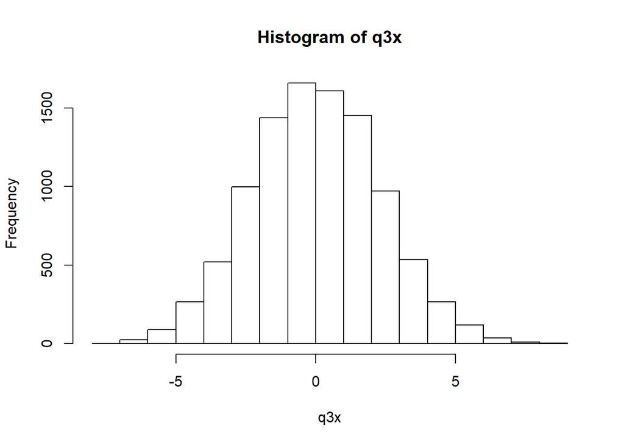

```r
set.seed(904971914)
X<-rnorm(1,0,1)
q3x<-c(X)
for (i in 1:10000){
  e<-rnorm(1,0,1)
  X<-X*0.9 + e
  q3x<-c(q3x,X)
}

hist(q3x)
```

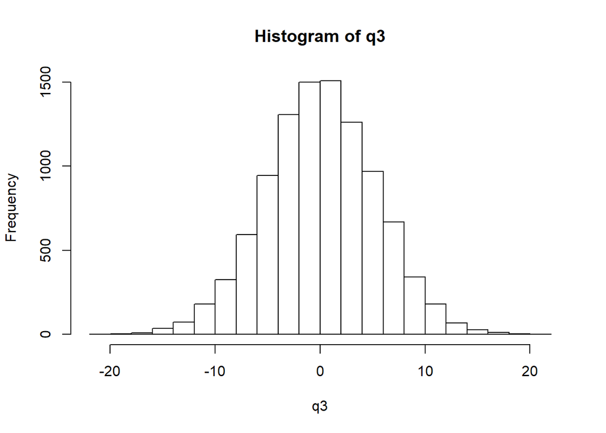

```r
q3<-rnorm(10000,0,1/0.19)

hist(q3)
```

```r
mean(q3x)
```

```
## [1] 0.02871766
```

```r
sd(q3x)
```

```
## [1] 2.284821
```

```r
mean(q3)
```

```
## [1] 0.05396002
```

```r
sd(q3)
```

```
## [1] 5.248578
```

The mean is the same, but the standard deviation is about only a half.

## Question 4

**(a)**
$$
$$\begin{eqnarray}
\pi(\lambda|y) &\propto& f(y|\lambda) * \pi(\lambda)\\
&\propto&\Pi_{i=1}^n(\frac {e^{-\lambda}\lambda^{y_i}}{y_i!}) * \frac {\beta^a}{\Gamma(a)}\lambda^{a-1}e^{-\beta\lambda}\\
&\propto& \frac {\beta^a}{\Gamma(a)*\sum_{i=1}^ny_i!}\lambda^{a-1+\sum _{i=1}^ny_i}e^{-\beta\lambda-n\lambda}\\
&\propto& \lambda^{a+\sum _{i=1}^ny_i-1}e^{-(\beta+n)\lambda}\\
&\propto&Gamma(a+\sum _{i=1}^ny_i\space , \space \beta+n)
\end{eqnarray}$$

$$

**(b)**
$$
$$\begin{eqnarray}
E(\lambda|y)&=& \frac { a+\sum _{i=1}^ny_i} {\beta+n}\\
&=& \frac {a} {\beta+n}+\frac { \sum _{i=1}^ny_i} {\beta+n}\\
&=& \frac {a} {\beta+n}*\frac {\beta}{\beta} +\frac { \sum _{i=1}^ny_i} {\beta+n}*\frac{n}{n}\\
&=& \frac {\beta} {\beta+n}*\frac {a}{\beta} +\frac { \sum _{i=1}^ny_i} {n}*\frac{n}{\beta+n}\\
&=& w* E(\lambda)+(1-w)*\bar{y},w=\frac{\beta}{\beta+n}
\end{eqnarray}$$

$$

**(c)**
$$
$$\begin{eqnarray}
lim_{n->\infty}\frac {\beta}{\beta+n}=0\\
lim_{n->\infty}E(\lambda|y)=\bar{y}
\end{eqnarray}$$

$$ It is the sample mean. It means that as number of samples increases, the sample mean will dominate the posterior mean.

**(d)**

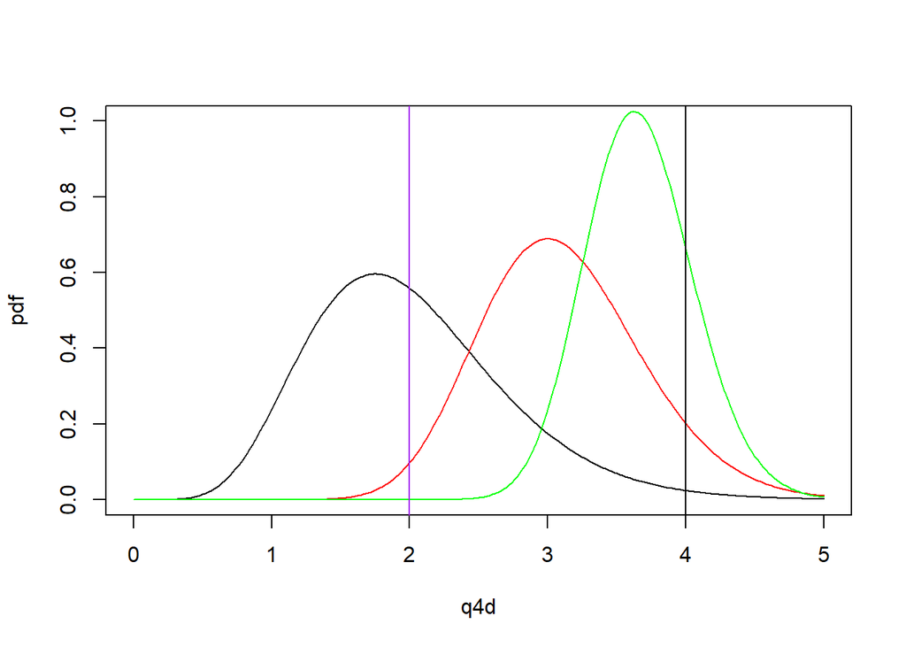

```r
q4d<-seq(0,5,by=0.02)
q4d_pdf<-dgamma(q4d,shape=8,rate=4)
q4d_p1<-dgamma(q4d,shape=8+20,rate=4+5)
q4d_p2<-dgamma(q4d,shape=8+80,rate=4+20)

{
plot(q4d,q4d_pdf,type="l",ylim=c(0,1),ylab= "pdf")
lines(q4d,q4d_p1,col='red')
lines(q4d,q4d_p2,col='green')
abline(v = 2,col='purple')
abline(v = 4)
}
```

The prior mean is 2, and the sample mean is 4. The posterior mean is shifting from the prior mean towards the sample mean as n increases.

**(e)**

```r
qgamma(0.025,shape=8+20,rate=4+5)
```

```
## [1] 2.067311
```

```r
qgamma(0.975,shape=8+20,rate=4+5)
```

```
## [1] 4.364842
```

```r
qgamma(0.025,shape=8+80,rate=4+20)
```

```
## [1] 2.940774
```

```r
qgamma(0.975,shape=8+80,rate=4+20)
```

```
## [1] 4.471424
```

The 95% credible interval for (i) is (2.07,4.36), meaning that there is a 95% probability that the true lambda falls in this interval after the observations Y=y.

The 95% credible interval for (ii) is (2.94,4.47), meaning that there is a 95% probability that the true lambda falls in this interval after the observations Y=y.

## Question 5

**(a)**  
1.Choose N($\mu$,$\sigma$) as the proposal distribution g(.|Xt).  
2.Generate X0 from g(.|Xt).  
3.Repeatedly:  
3(1). Generate Y from g(.|Xt)  
3(2). Generate U from uniform(0,1)  
3(3). Compute r = (f(Y)*g(Xt|Y)) (f(Xt)g(Y|Xt))  
3(4). if U<r, X(t+1) = Y, otherwise, X(t+1)=Xt  
3(5). increment t

**(b)**

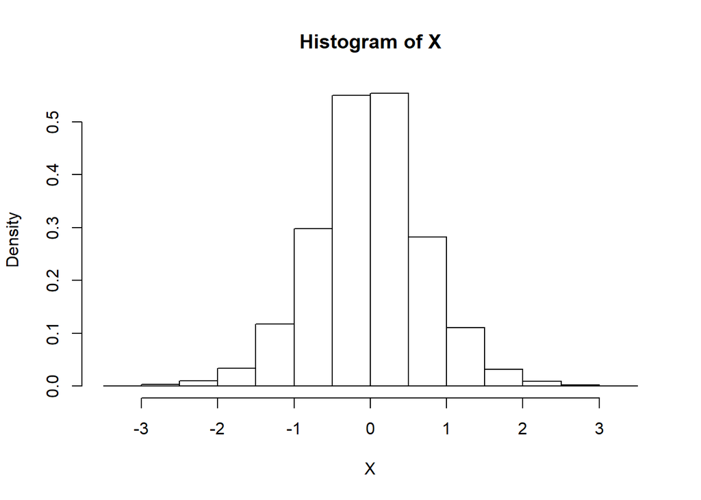

```r
set.seed(904971914)
n<-10000
X<-rnorm(1,0,1)
for(t in 2:n){
  Y<-rnorm(1,0,1)

 # r<-dcauchy(Y,0,1)*dnorm(X[t-1],0,1)/ (dcauchy(X[t-1])*dnorm(Y,0,1))
  r<-dcauchy(Y,0,1)/dcauchy(X[t-1],0,1)
  r<-min(r,1)
  U<-runif(1,0,1)
  if(U<r){
    X[t]<-Y
  }
  else{
    X[t]<-X[t-1]
  }
}
hist(X,prob=T)
```

**(c)**

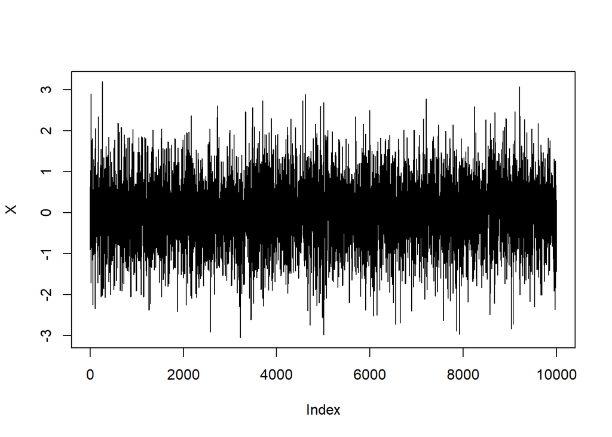

```r
test<-seq(0.01,0.99,by=0.01)
q5c<-qcauchy(test,location=0,scale=1)
plot(X,type='l')
```

```r
summary(X[501:n])
```

```
##      Min.   1st Qu.    Median      Mean   3rd Qu.      Max.
## -3.049276 -0.458597 -0.007467 -0.009689  0.430399  3.071668
```

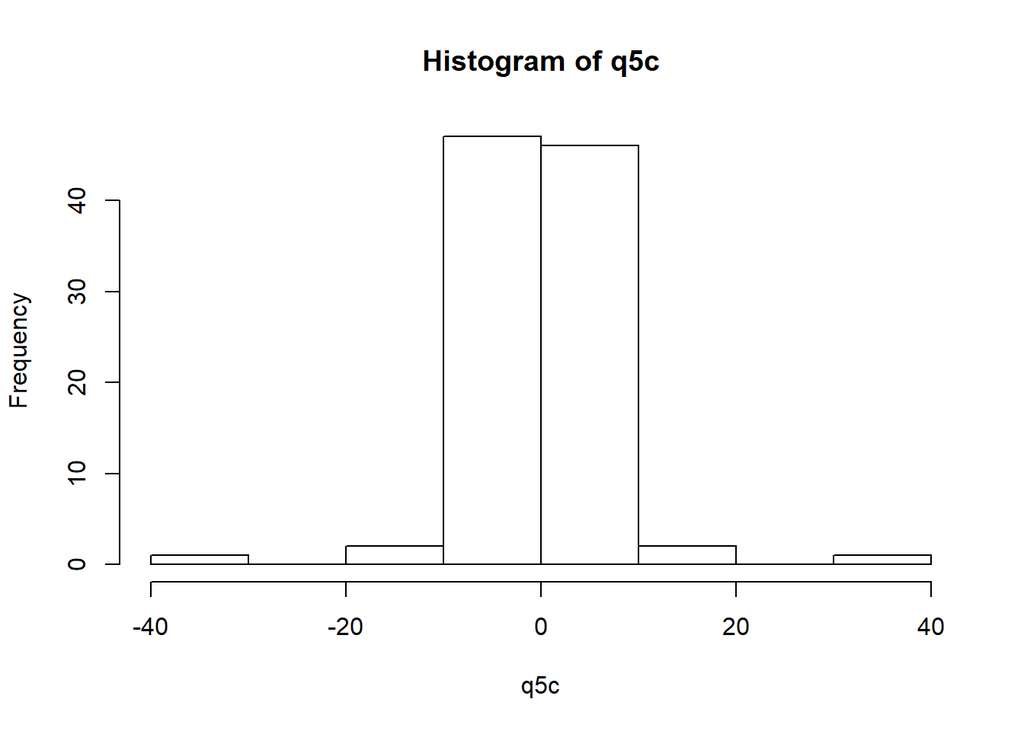

```r
hist(q5c)
```

## Question 6

**(b)**

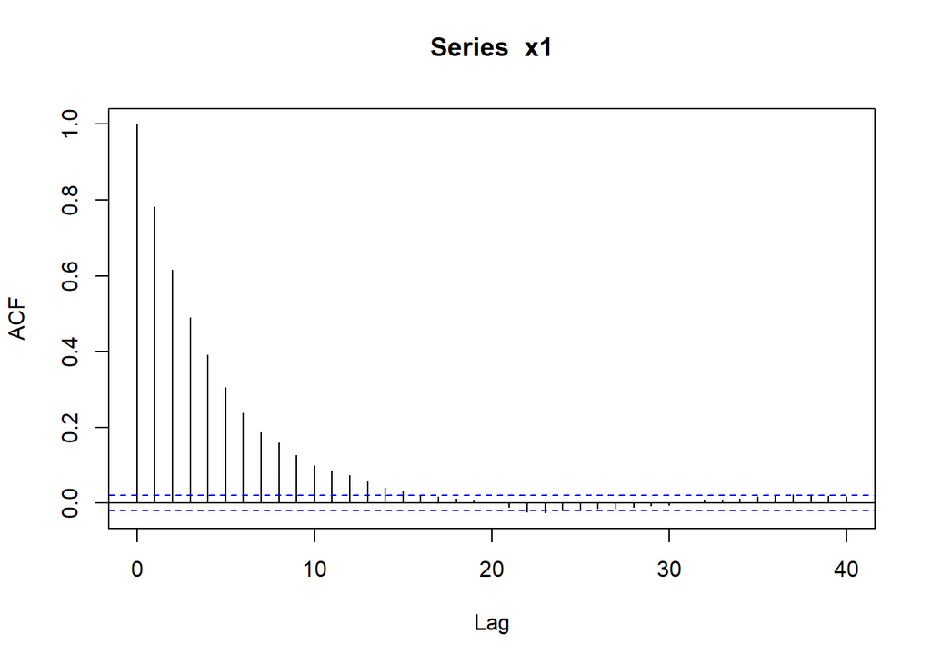

```r
set.seed(904971914)
fmu<-function(x,y){
  exp(-lbeta(533,6)+532*log(x)-532*log(1+x)-7*log(1+x))
}

fr<-function(x,y){
  a<-532* (log(y)-log(x))
  b<-539*(log(1+x)-log(1+y))
  return(exp(a+b))


}
m <- 10000
x1 <- numeric(m)
a <- 5
x1[1] <- rlnorm(1)
k <- 0
u <- runif(m)

for (i in 2:m){
  xt <- x1[i-1]
  y <- rgamma(1, shape=a, rate=a/xt)
  r <- fr(xt, y)*dgamma(xt, shape=a, rate=a/y)/dgamma(y, shape=a, rate=a/xt)
  if(u[i] <=r){
    x1[i] <- y
  }else {
    x1[i] <- xt
    k <- k+1
  }
}



acf(x1)
```